# KEY: Exam 02

## Load packages

```r
library(tidyverse)
library(NHANES)
library(infer)
library(broom)
```

## Questions

### Question 1

**In this analysis we will work data from only a subset of the participants: adults aged 26 to 64, inclusive, whose employment status, encoded in the variable `Work`, is known, i.e. not `NA`. Before you proceed, confirm that this leaves you with 5,125 observations. You will use this modified dataset for the remainder of your analysis.**

```r
nhanes_sub <- NHANES %>%
  filter(
    between(Age, 26, 64),
    !is.na(Work)
  )
nrow(nhanes_sub)
```

```
## [1] 5125
```

### Question 2

**First, we’ll analyze blood pressures of participants. There are a few variables in the dataset relating to blood pressure. Blood pressure of participants was measured three times (e.g. `BPSys1`, `BPSys2`, and `BPSys3`), and the average of these three measurements was also recorded (e.g. `BPSysAve`). Why did the surveyers measure the blood pressure of participants multiple times and also record the average?**

Take average to reduce measurement error.

### Question 3

**Visualize the relationship between systolic blood pressure (`BPSysAve`) and `Work` status of respondents, and describe the relationship using appropriate summary statistics.**

There does not seem to be a relationship between work status and systolic BP. The distributions (centers, spreads, and shapes) seem rouhgl similar with a higher number of outliers on the higher BP range than the lower.

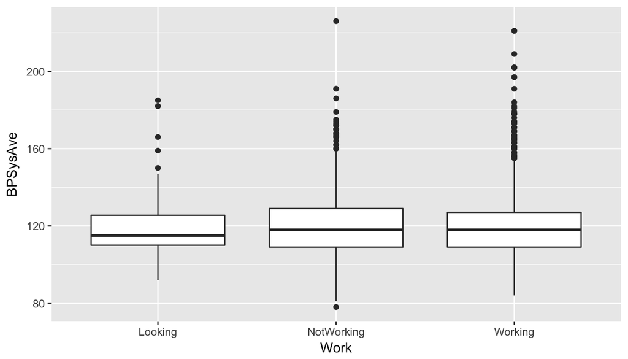

```r
ggplot(data = nhanes_sub, aes(x = Work, y = BPSysAve)) +
  geom_boxplot()
```

```r
nhanes_sub %>%
  group_by(Work) %>%
  summarise(xbar = mean(BPSysAve, na.rm = TRUE))
```

```
## # A tibble: 3 x 2
##   Work        xbar
##   <fct>      <dbl>
## 1 Looking     118.
## 2 NotWorking  120.
## 3 Working     119.
```

### Question 4

**Describe the simulation scheme for (a) conducting a hypothesis test for evaluating whether average systolic blood pressures are different for Americans who are `"Working"` and `"NotWorking"`, and (b) creating a confidence interval for estimating the difference between the average systolic blood pressures for Americans who are `"Working"` and `"NotWorking"`. Be as precise as possible, and use information from the actual data (e.g. sample sizes, etc.) in your answer.**

```r
nhanes_BPSysAve_noLooking <- nhanes_sub %>%
  filter(
    !is.na(BPSysAve),
    Work != "Looking"
  )
nrow(nhanes_BPSysAve_noLooking)
```

```
## [1] 4761
```

```r
nhanes_BPSysAve_noLooking %>%
  group_by(Work) %>%
  summarise(n = n(), xbar = mean(BPSysAve))
```

```
## # A tibble: 2 x 3
##   Work           n  xbar
##   <fct>      <int> <dbl>
## 1 NotWorking  1203  120.
## 2 Working     3558  119.
```

Is average systolic BP different for Americans who are working and not working?

- Step 1: Write the systolic BP of people who are working and not working on 4,761 index cards.
- Step 2: Shuffle the cards and split into two groups: One group of size 1,203 for not working and other group of size 3,558 for working.
- Step 3: Calculate the mean systolic BP in these two simulated groups, and record the difference (in the order not working - working).
- Step 4: Repeat steps 2 and 3 1000 times.
- Step 5: Calculate the p-value as the proportion of simulations that resulted in a simulated difference of 1.1573 or higher, times 2.

Construct a confidence intertval for the difference in average systolic BP different between Americans who are working and not working?

- Step 1: Write the systolic BP of not working people on 1,203 index cards and the systolic BP of working people on 3,558 index cards. Keep the cards for not working and working people in separate piles.
- Step 2: Randomly sample, with replacement, within each of of the groups, with sample sizes equal to the original group sizes.
- Step 3: Calculate the mean systolic BP in these two simulated groups, and record the difference (in the order not working - working).
- Step 4: Repeat steps 2 and 3 1000 times.
- Step 5: Calculate the 95% confidence interval as the middle 95% of the bootstrap distribution generated in Step 4.

### Question 5

**Conduct the hypothesis test you described in the previous question. Use a significance level of 5%. If you find a significant difference, also estimate this difference in mean systolic blood pressures of Americans who are `"Working` and `"NotWorking"`. Use a confidence interval at the equivalent confidence level to the hypothesis test. (Note: For this question, omit participants whose `Work` status is `"Looking"`.)**

Hypothesis test:

- Null hypothesis: Average systolic BP is same for people who are working and not working.
- Alternative hypothesis: Average systolic BP is different for people who are working and not working.
- p-value: Since the p-value is lower than 5%, we reject the null hypothesis in favour of the alternative. The data provide convincing evidence of a difference in average systolic BP between Americans who are working and who are not.

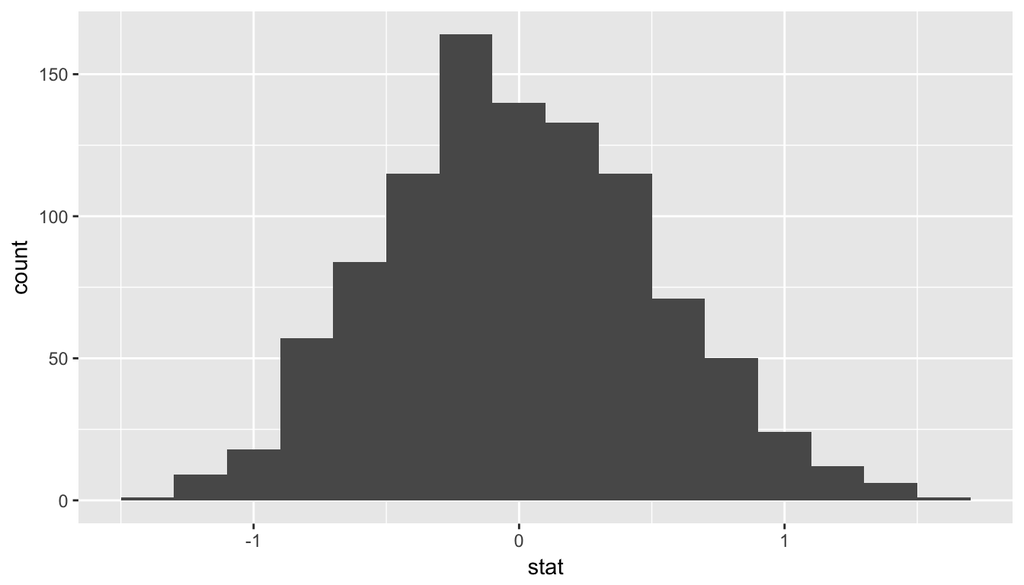

```r
nsim <- 1000

null_dist <- nhanes_BPSysAve_noLooking %>%
  specify(response = BPSysAve, explanatory = Work) %>%
  hypothesize(null = "independence") %>%
  generate(reps = nsim, type = "permute") %>%
  calculate(stat = "diff in means", order = c("NotWorking", "Working"))

ggplot(null_dist, aes(x = stat)) +
  geom_histogram(binwidth = 0.2)
```

```r
obs_diff <- 120.1430 - 118.9857

null_dist %>%
  filter(stat >= obs_diff) %>%
  summarise(pvalue = 2 * (n() / nsim))
```

```
## # A tibble: 1 x 1
##   pvalue
##    <dbl>
## 1 0.0240
```

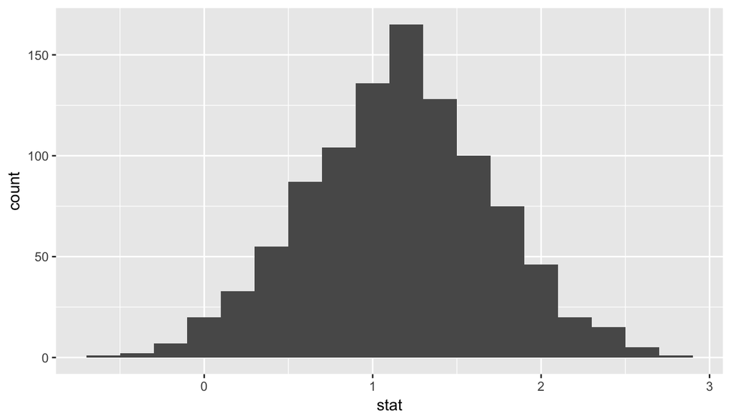

```r
boot_dist <- nhanes_BPSysAve_noLooking %>%
  specify(response = BPSysAve, explanatory = Work) %>%
  generate(reps = nsim, type = "bootstrap") %>%
  calculate(stat = "diff in means", order = c("NotWorking", "Working"))

ggplot(boot_dist, aes(x = stat)) +
  geom_histogram(binwidth = 0.2)
```

```r
boot_dist %>%
  summarise(l = quantile(stat, 0.025),
            u = quantile(stat, 0.975))
```

```
## Response: BPSysAve (integer)
## Explanatory: Work (factor)
## # A tibble: 1 x 2
##        l     u
##    <dbl> <dbl>
## 1 0.0766  2.23
```

### Question 6

**Create a new variable that indicates whether a participant gets a healthy amount of sleep, which is defined by the National Sleep Foundation as 7 to 9 hours per night for adults between the ages of 26 and 64. (a) What percent of the sample get a healthy amount of sleep? What percent get an unhealthy amount of sleep? Use summary statistics to answer this question. (b) What percent of participants who are working, not working, and looking for work get a healthy amount of sleep? Calculate and visualise these percentages.**

Part a. Create the new variable.

```r
nhanes_sub <- nhanes_sub %>%
  mutate(sleep_health = ifelse(between(SleepHrsNight, 7, 9), "healthy", "unhealthy"))
```

Part b. Calculate and visualize the proportion of healthy sleepers among the work categories.

```r
nhanes_sub %>%
  count(Work, sleep_health) %>%
  group_by(Work) %>%
  mutate(prop = n / sum(n)) %>%
  filter(sleep_health == "healthy")
```

```
## # A tibble: 3 x 4
## # Groups:   Work [3]
##   Work       sleep_health     n  prop
##   <fct>      <chr>        <int> <dbl>
## 1 Looking    healthy        124 0.656
## 2 NotWorking healthy        713 0.567
## 3 Working    healthy       2233 0.607
```

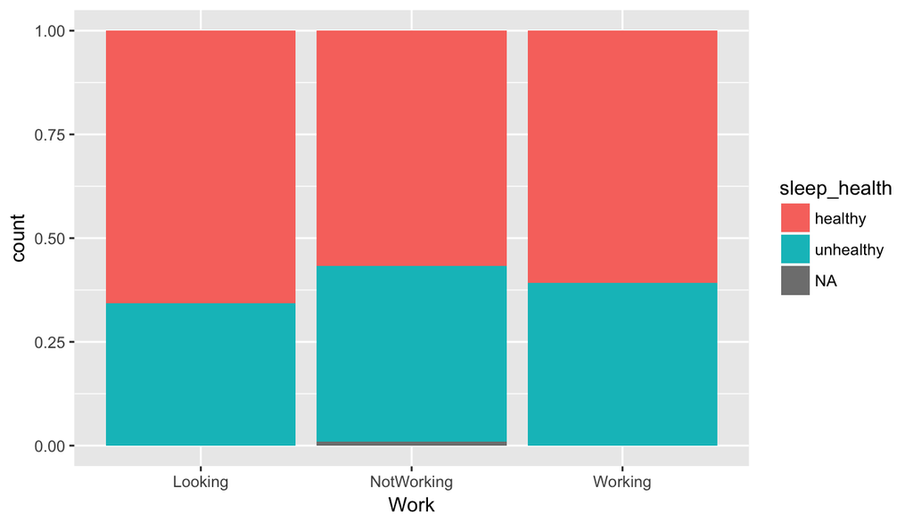

```r
ggplot(data = nhanes_sub, aes(x = Work, fill = sleep_health)) +
  geom_bar(position = "fill")
```

### Question 7

**Create two subsets of the dataset: one for healthy sleepers and one for unhealthy sleepers. How many observations are in each dataset?**

```r
healthy_sleep <- nhanes_sub %>%
  filter(sleep_health == "healthy")
unhealthy_sleep <- nhanes_sub %>%
  filter(sleep_health == "unhealthy")
```

```r
nrow(healthy_sleep)
```

```
## [1] 3070
```

```r
nrow(unhealthy_sleep)
```

```
## [1] 2041
```

### Question 8

**Among those who get a healthy amount of sleep, do these data provide convincing evidence of a difference in average systolic blood pressures of participants who are and are not working? Use a significance level of 5%. If the difference is statistically significant, also include a confidence interval (at the equivalent confidence level) estimating the magnitude of the average systolic blood pressure difference.**

Hypothesis test:

- Null hypothesis: Among people who get a healthy amount of sleep, average systolic BP is same for people who are working and not working.
- Alternative hypothesis: Among people who get a healthy amount of sleep, average systolic BP is different for people who are working and not working.
- p-value: Since the p-value is lower than 5%, we reject the null hypothesis in favour of the alternative. For Americans who get a healthy amount of sleep, the data provide convincing evidence of a difference in average systolic BP between those who are working and who are not.

```r
healthy_sleep_BPSysAve_noLooking <- healthy_sleep %>%
  filter(
    !is.na(BPSysAve),
    Work != "Looking"
  )

healthy_sleep_BPSysAve_noLooking %>%
  group_by(Work) %>%
  summarise(xbar = mean(BPSysAve))
```

```
## # A tibble: 2 x 2
##   Work        xbar
##   <fct>      <dbl>
## 1 NotWorking  120.
## 2 Working     118.
```

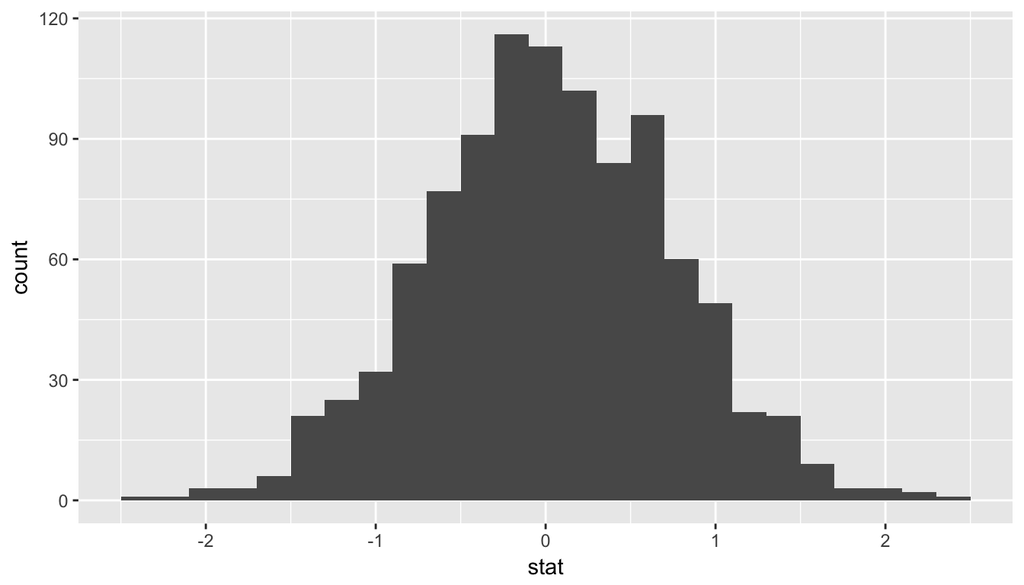

```r
nsim <- 1000

null_dist <- healthy_sleep_BPSysAve_noLooking %>%
  specify(response = BPSysAve, explanatory = Work) %>%
  hypothesize(null = "independence") %>%
  generate(reps = nsim, type = "permute") %>%
  calculate(stat = "diff in means", order = c("NotWorking", "Working"))

ggplot(null_dist, aes(x = stat)) +
  geom_histogram(binwidth = 0.2)
```

```r
obs_diff <- 120 - 118

null_dist %>%
  filter(stat >= obs_diff) %>%
  summarise(pvalue = 2 * (n() / nsim))
```

```
## # A tibble: 1 x 1
##    pvalue
##     <dbl>
## 1 0.00600
```

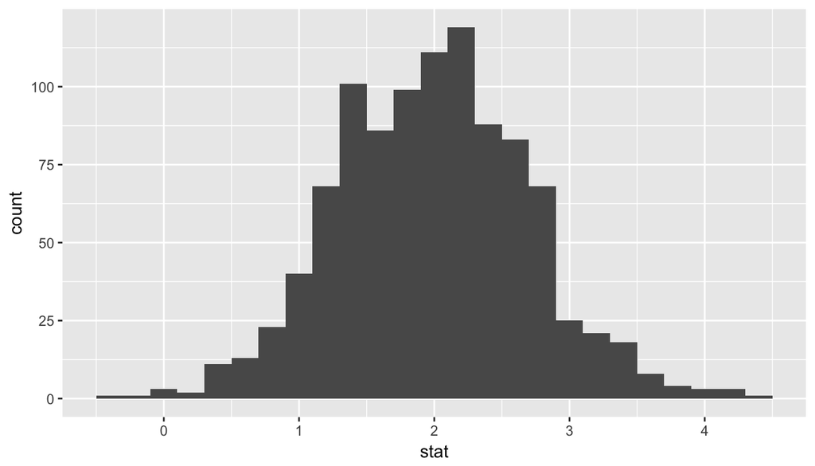

```r
boot_dist <- healthy_sleep_BPSysAve_noLooking %>%
  specify(response = BPSysAve, explanatory = Work) %>%
  generate(reps = nsim, type = "bootstrap") %>%
  calculate(stat = "diff in means", order = c("NotWorking", "Working"))

ggplot(boot_dist, aes(x = stat)) +
  geom_histogram(binwidth = 0.2)
```

```r
boot_dist %>%
  summarise(l = quantile(stat, 0.025),
            u = quantile(stat, 0.975))
```

```
## Response: BPSysAve (integer)
## Explanatory: Work (factor)
## # A tibble: 1 x 2
##       l     u
##   <dbl> <dbl>
## 1 0.594  3.39
```

### Question 9

**Among those who get an unhealthy amount of sleep, do these data provide convincing evidence of a difference in average systolic blood pressures of participants who are and are not working? Use a significance level of 5%.If the difference is statistically significant, also include a confidence interval (at the equivalent confidence level) estimating the magnitude of theaverage systolic blood pressure difference.**

Hypothesis test:

- Null hypothesis: Among people who don’t get a healthy amount of sleep, average systolic BP is same for people who are working and not working.
- Alternative hypothesis: Among people who don’t get a healthy amount of sleep, average systolic BP is different for people who are working and not working.
- p-value: Since the p-value is high, we fail to reject the null hypothesis in favour of the alternative. For Americans who don’t get a healthy amount of sleep, the data do not provide convincing evidence of a difference in average systolic BP between those who are working and who are not.

```r
unhealthy_sleep_BPSysAve_noLooking <- unhealthy_sleep %>%
  filter(
    !is.na(BPSysAve),
    Work != "Looking"
  )

unhealthy_sleep_BPSysAve_noLooking %>%
  group_by(Work) %>%
  summarise(xbar = mean(BPSysAve))
```

```
## # A tibble: 2 x 2
##   Work        xbar
##   <fct>      <dbl>
## 1 NotWorking  120.
## 2 Working     120.
```

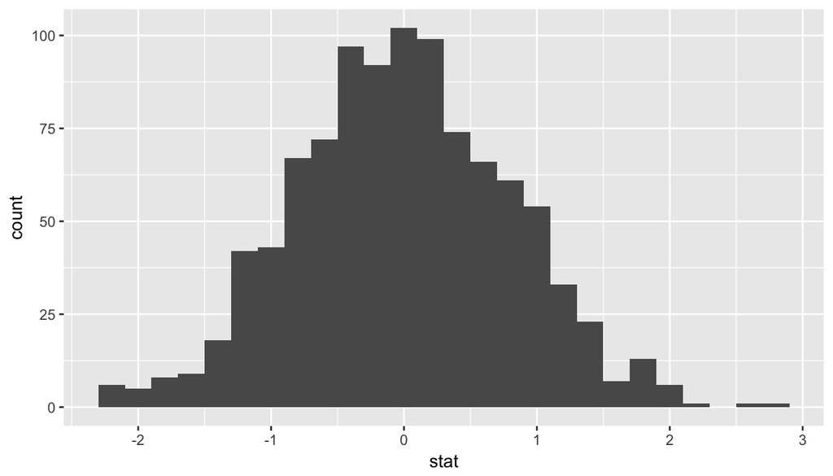

```r
null_dist <- unhealthy_sleep_BPSysAve_noLooking %>%
  specify(response = BPSysAve, explanatory = Work) %>%
  hypothesize(null = "independence") %>%
  generate(reps = nsim, type = "permute") %>%
  calculate(stat = "diff in means", order = c("NotWorking", "Working"))

ggplot(null_dist, aes(x = stat)) +
  geom_histogram(binwidth = 0.2)
```

```r
obs_diff <- 120 - 120

null_dist %>%
  filter(stat >= obs_diff) %>%
  summarise(pvalue = 2 * (n() / nsim))
```

```
## # A tibble: 1 x 1
##   pvalue
##    <dbl>
## 1  0.994
```

### Question 10

**What do your findings from these hypothesis tests suggest about whether or not getting a healthy amount of sleep might be a confounding variable in the relationship between work status and systolic blood pressure?**

That getting healthy amount of sleep or not can be a confounding variable in the relationship between work status and systolic BP.

### Question 11

**Fit a regression model predicting systolic blood pressure (`BPSysAve`) from `Age`, `BMI`, `TotChol`, `HealthGen`, `SmokeNow`,`DaysPhysHlthBad`, `DaysMentHlthBad`, `PhysActive`, `Work`, the categorical sleep health variable you created earlier and the interaction between `Work` and the categorical sleep health variable you created earlier. Display the coefficient estimates, and interpret the slope coefficients of `Age`, `SmokeNow`, and `HealthGen`.**

```r
m_full <- lm(BPSysAve ~ Age + BMI + TotChol + HealthGen + SmokeNow +
DaysPhysHlthBad + DaysMentHlthBad + PhysActive + Work + sleep_health +
Work * sleep_health, data = nhanes_sub)

as_tibble(tidy(m_full)) %>%
  select(term, estimate)
```

```
## # A tibble: 17 x 2
##    term                                 estimate
##    <chr>                                   <dbl>
##  1 (Intercept)                           86.4
##  2 Age                                    0.385
##  3 BMI                                    0.236
##  4 TotChol                                1.48
##  5 HealthGenVgood                        -0.183
##  6 HealthGenGood                          2.43
##  7 HealthGenFair                          4.76
##  8 HealthGenPoor                          5.45
##  9 SmokeNowYes                            1.06
## 10 DaysPhysHlthBad                       -0.134
## 11 DaysMentHlthBad                       -0.0566
## 12 PhysActiveYes                         -0.468
## 13 WorkNotWorking                         2.73
## 14 WorkWorking                            0.472
## 15 sleep_healthunhealthy                 -4.22
## 16 WorkNotWorking:sleep_healthunhealthy  -0.0399
## 17 WorkWorking:sleep_healthunhealthy      5.38
```

- `Age`: All else held constant, each additional year in age is associated, on average, with an increase in systolic BP of 0.385 mmHg.
- `SmokeNow`: All else held constant, those who are smokers are predicted to have, on average, systolic BP that is 1.06 mmHg higher than those who are not smokers.
- `HealthGen`: All else held constant, those who have
  - very good health are predicted to have, on average, systolic BP that is -0.183 lower
  - good health are predicted to have, on average, systolic BP that is 2.43 higher
  - fair health are predicted to have, on average, systolic BP that is 4.76 higher
  - poor health are predicted to have, on average, systolic BP that is 5.45 higher than those who have excellent health.

### Question 12

**Write the linear models for those who get a healthy amount of sleep and those who do not based on your model in the previous question. Interpret the slope coefficient for `Work` for both models.**

Healthy sleep: 86.4 + 0.385 x Age + 0.236 x BMI + 1.48 x TotChol - 0.183 x HealthGenVgood + 2.43 x HealthGenGood + 4.76 x HealthGenFair + 5.45 x HealthGenPoor + 1.06 x SmokeNowYes - 0.134 x DaysPhysHlthBad - 0.0566 x DaysMentHlthBad - 0.468 x PhysActiveYes + 2.73 x WorkNotWorking + 0.472 x WorkWorking

- Among those who get a healthy amount of sleep, all else held constant, those who are not working are predicted to have, on average, systolic BP that is 2.73 mmHg higher than those who are looking.
- Among those who get a healthy amount of sleep, all else held constant, those who are working are predicted to have, on average, systolic BP that is 0.472 mmHg higher than those who are looking.

Unhealthy sleep: 82.18 + 0.385 x Age + 0.236 x BMI + 1.48 x TotChol - 0.183 x HealthGenVgood + 2.43 x HealthGenGood + 4.76 x HealthGenFair + 5.45 x HealthGenPoor + 1.06 x SmokeNowYes - 0.134 x DaysPhysHlthBad - 0.0566 x DaysMentHlthBad - 0.468 x PhysActiveYes + 2.6901 x WorkNotWorking + 5.852 x WorkWorking

- Among those who don’t get a healthy amount of sleep, all else held constant, those who are not working are predicted to have, on average, systolic BP that is 2.6901 mmHg higher than those who are looking.
- Among those who don’t get a healthy amount of sleep, all else held constant, those who are working are predicted to have, on average, systolic BP that is 5.852 mmHg higher than those who are looking.

### Question 13

**Perform model selection based on AIC, and print a summary output of the final model.**

```r
nhanes_sub_formodel <- nhanes_sub %>%
  select(BPSysAve, Age, BMI, TotChol, HealthGen, SmokeNow,
         DaysPhysHlthBad, DaysMentHlthBad, PhysActive, Work, sleep_health) %>%
  na.omit()
m_full <- lm(BPSysAve ~ Age + BMI + TotChol + HealthGen + SmokeNow +
DaysPhysHlthBad + DaysMentHlthBad + PhysActive + Work + sleep_health +
Work * sleep_health, data = nhanes_sub_formodel)
m_selected <- step(m_full)
```

```
## Start:  AIC=10567.43
## BPSysAve ~ Age + BMI + TotChol + HealthGen + SmokeNow + DaysPhysHlthBad +
##     DaysMentHlthBad + PhysActive + Work + sleep_health + Work *
##     sleep_health
##
##                     Df Sum of Sq    RSS   AIC
## - PhysActive         1      89.7 418312 10566
## - DaysMentHlthBad    1     398.7 418622 10567
## <none>                           418223 10567
## - SmokeNow           1     470.0 418693 10568
## - DaysPhysHlthBad    1    1743.8 419967 10574
## - Work:sleep_health  2    2917.4 421140 10577
## - HealthGen          4    5194.4 423417 10584
## - BMI                1    3930.0 422153 10584
## - TotChol            1    4875.7 423099 10588
## - Age                1   31132.2 449355 10706
##
## Step:  AIC=10565.85
## BPSysAve ~ Age + BMI + TotChol + HealthGen + SmokeNow + DaysPhysHlthBad +
##     DaysMentHlthBad + Work + sleep_health + Work:sleep_health
##
##                     Df Sum of Sq    RSS   AIC
## - DaysMentHlthBad    1       376 418688 10566
## <none>                           418312 10566
## - SmokeNow           1       570 418882 10566
## - DaysPhysHlthBad    1      1687 420000 10572
## - Work:sleep_health  2      2920 421233 10576
## - BMI                1      4193 422506 10583
## - HealthGen          4      5576 423888 10584
## - TotChol            1      4953 423266 10587
## - Age                1     31802 450114 10708
##
## Step:  AIC=10565.61
## BPSysAve ~ Age + BMI + TotChol + HealthGen + SmokeNow + DaysPhysHlthBad +
##     Work + sleep_health + Work:sleep_health
##
##                     Df Sum of Sq    RSS   AIC
## <none>                           418688 10566
## - SmokeNow           1       588 419276 10566
## - DaysPhysHlthBad    1      2053 420741 10573
## - Work:sleep_health  2      2993 421681 10576
## - HealthGen          4      5322 424010 10582
## - BMI                1      4296 422984 10584
## - TotChol            1      4948 423636 10587
## - Age                1     33367 452055 10714
```

```r
as_tibble(tidy(m_selected))
```

```
## # A tibble: 15 x 5
##    term                             estimate std.error statistic   p.value
##    <chr>                               <dbl>     <dbl>     <dbl>     <dbl>
##  1 (Intercept)                        85.4      3.59     23.8    5.42e-110
##  2 Age                                 0.393    0.0315   12.5    2.25e- 34
##  3 BMI                                 0.244    0.0546    4.47   8.16e-  6
##  4 TotChol                             1.49     0.311     4.80   1.70e-  6
##  5 HealthGenVgood                     -0.164    1.38     -0.119  9.05e-  1
##  6 HealthGenGood                       2.45     1.37      1.79   7.39e-  2
##  7 HealthGenFair                       4.74     1.54      3.07   2.15e-  3
##  8 HealthGenPoor                       5.28     2.41      2.19   2.88e-  2
##  9 SmokeNowYes                         1.16     0.702     1.65   9.81e-  2
## 10 DaysPhysHlthBad                    -0.142    0.0460   -3.09   2.02e-  3
## 11 WorkNotWorking                      2.66     2.44      1.09   2.75e-  1
## 12 WorkWorking                         0.441    2.30      0.192  8.48e-  1
## 13 sleep_healthunhealthy              -4.28     3.37     -1.27   2.04e-  1
## 14 WorkNotWorking:sleep_healthunhe…   -0.119    3.60     -0.0331 9.74e-  1
## 15 WorkWorking:sleep_healthunhealt…    5.38     3.46      1.56   1.20e-  1
```

### Question 14

**Interpret R-squared for your final model in the previous question.**

```r
glance(m_full)
```

```
##   r.squared adj.r.squared    sigma statistic      p.value df    logLik
## 1 0.1326809     0.1255571 14.65242   18.6251 7.880826e-50 17 -8054.927
##        AIC      BIC deviance df.residual
## 1 16145.85 16246.35 418222.8        1948
```

Approximately 13.3% of variability in systolic BP is explained by the model.

### Extra credit

I believe the answer is no, it doesn’t match the description. If you find someone who has the right code you can add to the answer. All or nothing grading.

### Style and organization

In this category we looked for a variety of features, including, but not limited to the following:

- Content:
  - References cited
  - Questions answered in order
  - A written explanation of approach included for each question
  - Appropriate formatting of text: fonts not larger than necessary, headings used properly, etc.
- Code formatting:
  - Use tidyverse code
  - No more than ~80 characters of code per line (esp happens in comments)
  - Spaces around `=`, after `#`, after `,`, etc.
  - New line for each `dplyr` function (lines end in `%>%`) or `ggplot` layer (lines end in `+`)
  - Proper indentation of pipes and ggplot layers
  - All chunks are labeled without spaces
  - No unwanted / commented out code left behind in the document
- Git:
  - Reasonable number of commites tracking progress throughout the assessment
  - Informative commit messages
  - Push both .md and .Rmd files